Each simulation used a rate parameter $\lambda = 0.2$ used to produce n = 40 random variables. The mean & standard deviation of the 40 values were then calculated 10,000 times.

```r
set.seed(1230); lambda <- .2; n <- 40; no_sim <- 10000
mean_values <- NULL; mean_sds <- NULL
for (i in 1:no_sim){
  values <- rexp(n, lambda); means <- mean(values); sds <- sd(values)
  mean_values  <- c(mean_values, means); mean_sds <- c(mean_sds, sds)
}
avg <- mean(mean_values); s <- sd(mean_values)
```

The expected value for an exponential distribution is $\mathbb{E}[X] = 1 / lambda$ which is equal to 5 in this case. The mean for the experiment was calculated to be 5.00. As expected, due to the CLT, the expected value of the sample mean is equal to the mean it’s trying to estimate. The distribution of the sample mean is gausian, centered at 5 & concentrated at the center as shown below.

```
## [1] 5.003
```

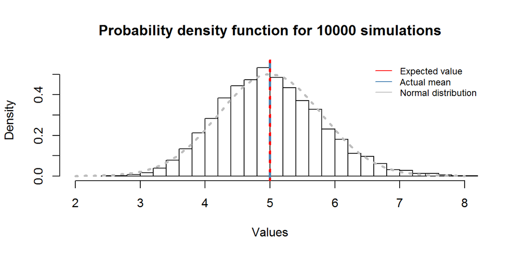

```
## [1] 0.7969
```

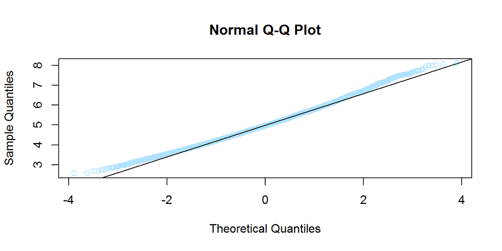

The 95% confidence interval of each simulation was worked out using each simulation’s own standard deviaton and mean according to the equation $\bar{X} \pm 1.96 sigma/\sqrt{n}$. The coverage was computed as the percent of times the true mean fell within each interval’s confidence interval.

```r
upper <- mean_values +  1.96 * (mean_sds/sqrt(n))
lower <- mean_values -  1.96 * (mean_sds/sqrt(n))
sum(lower < 5 & 5 < upper)/no_sim * 100
```

```
## [1] 92.23
```

For visualization purposes, an extra experiment for 100 simulations was run & the confidence interval for each simulation was plotted.

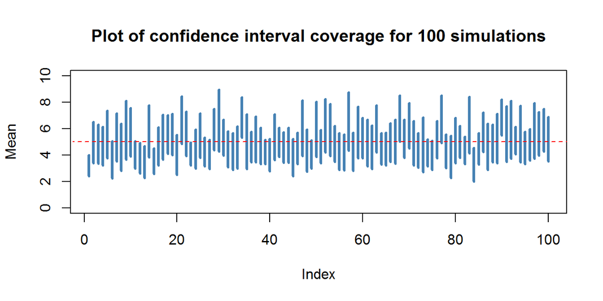